# смешаные линейные модели

## Вы узнаете

- Что такое смешаные модели и когда они применяются
- Что такое фиксированные и случайные факторы

### Вы сможете

- Рассказать чем фиксированные факторы отличаются от случайных
- Привести примеры факторов, которые могут быть фиксированными или случайными в зависимости от задачи исследования
- Рассказать, что оценивает коэффициент внутриклассовой корреляции и вычислить его для случая с одним случайным фактором
- Подобрать смешаную линейную модель со случайным отрезком и случайным углом наклона в R при помощи методов максимального правдоподобия

## Многоуровневые данные

## Пример: Как время реакции людей зависит от бессонницы?

Данные из Belenky et al., 2003.  
В нулевой день эксперимента всем испытуемым давали поспать нормальное время. Начиная со следующей ночи давали спать по 3 часа.

- `Reaction` - среднее время реакции в серии тестов в день наблюдения, мс
- `Days` - число дней депривации сна
- `Subject` - номер субъекта

```r
library(lme4)
data(sleepstudy)
sl <- sleepstudy
head(sl, 3)
```

```
##   Reaction Days Subject
## 1      250    0     308
## 2      259    1     308
## 3      251    2     308
```

## Знакомство с данными

```r
str(sl)
```

```
## 'data.frame':    180 obs. of  3 variables:
##  $ Reaction: num  250 259 251 321 357 ...
##  $ Days    : num  0 1 2 3 4 5 6 7 8 9 ...
##  $ Subject : Factor w/ 18 levels "308","309","310",..: 1 1 1 1 1 1 1 1 1 1 ...
```

```r
# пропущенные значения
sum(!complete.cases(sl))
```

```
## [1] 0
```

```r
# число субъектов
length(unique(sl$Subject))
```

```
## [1] 18
```

## Знакомство с данными (продолжение)

```r
# сбалансирован ли объем выборки?
table(sl$Subject)
```

```
##
## 308 309 310 330 331 332 333 334 335 337 349 350 351 352 369 370 371
##  10  10  10  10  10  10  10  10  10  10  10  10  10  10  10  10  10
## 372
##  10
```

```r
with(sl, table(Subject, Days))
```

```
##        Days
## Subject 0 1 2 3 4 5 6 7 8 9
##     308 1 1 1 1 1 1 1 1 1 1
##     309 1 1 1 1 1 1 1 1 1 1
##     310 1 1 1 1 1 1 1 1 1 1
##     330 1 1 1 1 1 1 1 1 1 1
##     331 1 1 1 1 1 1 1 1 1 1
##     332 1 1 1 1 1 1 1 1 1 1
##     333 1 1 1 1 1 1 1 1 1 1
##     334 1 1 1 1 1 1 1 1 1 1
##     335 1 1 1 1 1 1 1 1 1 1
##     337 1 1 1 1 1 1 1 1 1 1
##     349 1 1 1 1 1 1 1 1 1 1
##     350 1 1 1 1 1 1 1 1 1 1
##     351 1 1 1 1 1 1 1 1 1 1
##     352 1 1 1 1 1 1 1 1 1 1
##     369 1 1 1 1 1 1 1 1 1 1
##     370 1 1 1 1 1 1 1 1 1 1
##     371 1 1 1 1 1 1 1 1 1 1
##     372 1 1 1 1 1 1 1 1 1 1
```

## Есть ли выбросы?

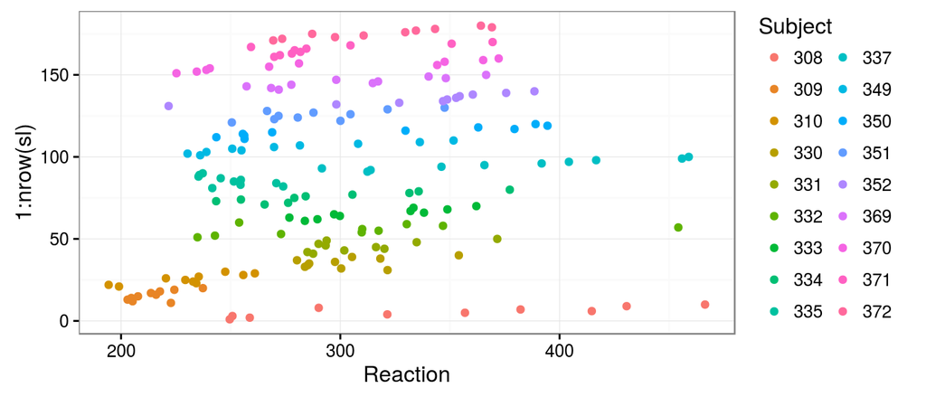

```r
library(ggplot2)
theme_set(theme_bw() + theme(legend.key = element_blank()))
update_geom_defaults("point", list(shape = 19))
# Есть ли наблюдения-выбросы? строим dot-plot
ggplot(sl, aes(x = Reaction, y = 1:nrow(sl), colour = Subject)) +
  geom_point() + guides(colour = guide_legend(ncol = 2))
```

>- Субъектов с необычным временем реакции нет  
>- Видно, что у разных субъектов время реакции различается. Есть быстрые, есть медленные. Межиндивидуальную изменчивость нельзя игнорировать.

## Что делать с разными субъектами?

Неправильные варианты:

- игнорировать структуру данных, не учитывать группирующий фактор
- учитывать группирующий фактор как обычно

Правильный вариант

- подобрать смешаную модель (в которой есть фиксированные и случайные факторы)

## Неправильный вариант 1. Не учитываем группирующий фактор.

\(Reaction_{i} = \beta_0 + \beta_1 Days_{i} + \epsilon_{i}\)

\(\epsilon_i \sim N(0, \sigma^2)\)  
\(i = 1, 2, ..., 180\) – общее число наблюдений

В матричном виде \(\mathbf{Reaction} = \mathbf{X} \boldsymbol{\beta} + \boldsymbol{\epsilon}\)

```r
wrong1 <- lm(Reaction ~ Days, data = sl)
```

Если мы не учитываем группирующий фактор, все будет "очень достоверно" из-за низких стандартных ошибок.  
Но в этом случае условие независимости будет нарушено, поэтому все не так как кажется.

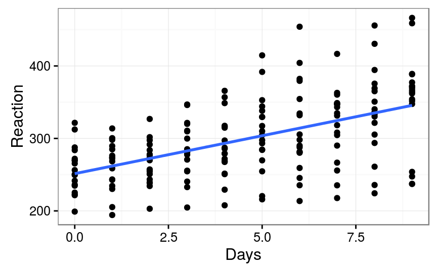

## Неправильный вариант 2. Группирующий фактор как фиксированный.

\(Reaction_{ij} = \beta_0 + \beta_1 Days_{j} + \beta_{2}Subject_{i = 2} + ... + \beta_{2}Subject_{i = 18} + \epsilon_{ij}\)

\(\epsilon_ij \sim N(0, \sigma^2)\) - остатки от регрессии  
\(i = 1, 2, ..., 18\) - субъект  
\(j = 1, 2, ..., 10\) - день

В матричном виде \(\mathbf{Reaction} = \mathbf{X} \boldsymbol{\beta} + \boldsymbol{\epsilon}\)

```r
wrong2 <- lm(Reaction ~ Days + Subject, data = sl)
```

Если мы учитываем группирующий фактор как обычно (как **фиксированный фактор**), придется оценивать слишком много параметров (18 для уровней группирующего фактора, 1 для `Days`, \(\epsilon\) — всего 20).  
При этом у нас всего 180 наблюдений. Чтобы получить удовлетворительную мощность, нужно минимум 10–20 наблюдений на каждый параметр (Harrell, 2013) — у нас 9.

## Что нам делать с этим множеством прямых?

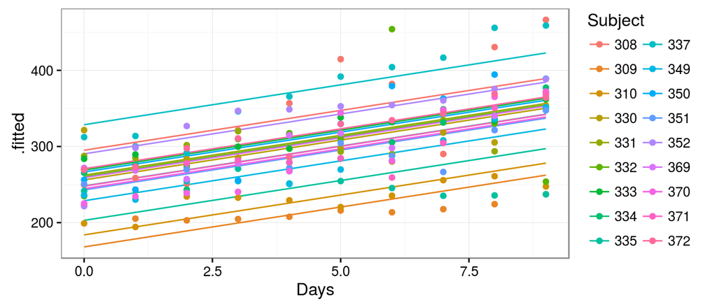

```r
wrong2_diag <- fortify(wrong2)
ggplot(wrong2_diag, aes(x = Days, colour = Subject)) +
  geom_line(aes(y = .fitted, group = Subject)) +
  geom_point(data = sl, aes(y = Reaction)) +
  guides(colour = guide_legend(ncol = 2))
```

- Нас не интересует, как различается время реакции каждого конкретного субъекта. Можем попытаться вместо подбора отдельных интерсептов, оценить разброс их значений.

## Можно посмотреть на группирующий фактор иначе!

Нам не важны конкретные значения на разных уровнях фактора. Мы можем представить, что эффект фактора — случайная величина. Мы можем оценить дисперсию между уровнями группирующего фактора.

Такие факторы называются **случайными факторами**, а модели с такими факторами называются **смешаными моделями**:

- Общие смешаные модели (general linear mixed models) — нормальное распределение зависимой переменной
- Обобщенные смешаные модели (generalized linear mixed models) — другие формы распределений зависимой переменной

## Фиксированные и случайные факторы

| Свойства | Фиксированные факторы | Случайные факторы |
| --- | --- | --- |
| Уровни фактора | фиксированные, заранее определенные и потенциально воспроизводимые уровни | случайная выборка из всех возможных уровней |
| Используются для тестирования гипотез | о средних значениях отклика между уровнями фактора \(H _{0}: μ _1 = μ _2 = · · · = μ _i = μ\) | о дисперсии отклика между уровнями фактора \(H _{0}: \sigma_{\alpha}^2 = 0\) |
| Выводы можно экстраполировать | только на уровни из анализа | на все возможные уровни |
| Число уровней фактора | **Осторожно!** Если уровней фактора слишком много, то нужно подбирать слишком много коэффициентов - должно быть много данных | **Важно!** Для точной оценки \(\sigma\) нужно нужно много уровней фактора - не менее 5 |

## Примеры фиксированных и случайных факторов

**Фиксированные факторы**

- Пол
- Низина/вершина
- Илистый/песчаный грунт
- Тень/свет
- Опыт/контроль

**Случайные факторы**

- Субъект, особь или площадка (если есть несколько измерений)
- Выводок
- Блок, делянка на участке
- Аквариум в лаб. эксперименте

## Какого типа эти факторы? От чего это зависит?

- Несколько произвольно выбранных градаций плотности моллюсков в полевом эксперименте, где плотностью манипулировали.
- Фактор размер червяка (маленький, средний, большой) в выборке червей.
- Деление губы Чупа на зоны с разной степенью распреснения.

## смешаные линейные модели

## смешаная линейная модель в общем виде

\[Y_i = X _i \times \boldsymbol{\beta} + Z_i \times b _i + \boldsymbol{\epsilon} _i\]

\(\mathbf{b} _i \sim N(0, \mathbf{D})\) - случайные эффекты нормально распределены со средним 0 и дисперсией \(d^2\)

\(\boldsymbol{\epsilon} _i \sim N(0, \boldsymbol{\sigma})\) - остатки модели нормально распределены со средним 0 и матрицей ковариаций \(\boldsymbol{\sigma}\)

\(\mathbf{X} _i \times \boldsymbol{\beta}\) - фиксированная часть модели

\(\mathbf{Z}_i \times \mathbf{b} _i\) - случайная часть модели

## В примере модель со случайным отрезком можно записать так:

\(Reaction_{ij} = \beta_0 + \beta_1 Days_{ij} + b_i + \epsilon_{ij}\)

\(b_{i} \sim N(0, d^2)\) - случайный эффект субъекта (intercept)  
\(\epsilon_{ij} \sim N(0, \boldsymbol{\sigma})\) - остатки модели  
\(i = 1, 2, ..., 18\) - субъекты  
\(j = 1, 2, ..., 10\) - дни

Для каждого субъекта \(i\) в матричном виде это записывается:

\[ \left( \begin{array}{c} Reaction _{i1} \\ Reaction _{i2} \\ \vdots \\ Reaction _{i10} \end{array} \right) = \left(\begin{array}{cc} 1 & Days _{i1} \\ 1 & Days _{i2} \\ \vdots \\ 1 & Days _{i10} \end{array} \right) \times \left( \begin{array}{c} \beta _0 \\ \beta _1 \end{array} \right) + \left( \begin{array}{c} 1 \\ 1 \\ \vdots \\ 1 \end{array} \right) \times b _{i} + \left( \begin{array}{c} \epsilon _{i1} \\ \epsilon _{i2}\\ \vdots \\ \epsilon _{i10} \end{array} \right)\]

что можно записать сокращенно так:

\[\mathbf{Reaction} _i = \mathbf{X} _i \times \boldsymbol{\beta} + \mathbf{Z} _i \times \mathbf{b} _i + \boldsymbol{\epsilon}_i\]

## Подбор смешаных моделей в R

Самые популярные пакеты - `nlme` (старый, иногда медленный, стабильный, хорошо документированный) и `lme4` (новый, быстрый, не такой стабильный, хуже документированный). Есть много других.

| Функция | `lme()` из `nlme` | `lmer()` из `lme4` | `glmer()` из `lme4` | `glmmPQL()` из `MASS` |
| --- | --- | --- | --- | --- |
| Распределение отклика | нормальное | нормальное | биномиальное, пуассоновское, гамма, квази-… | биномиальное, пуассоновское, гамма, квази-…, **отр. биномиальное** |
| Метод оценивания | ML, REML | ML, REML | ML, REML | PQL |
| Гетерогенность дисперсий | + | - | - | - |
| Корреляционные структуры | + | - | - | + |
| Доверительная вероятность (p-value) | + | - | - | + |

## Синтаксис для смешаных моделей в R

**Фиксированная часть модели** задается обычной двухсторонней формулой

`Y ~ 1 + X1 + ... + Xn`

**Случайная часть модели** - односторонняя формула. До вертикальной черты — перечислены факторы, влияющие на случайный угол наклона. После вертикальной черты — факторы, влияющие на случайный intercept.

`~ 1 + X1 + ... + Xn |A`

Вложенные друг в друга факторы указываются от крупного к мелкому через "/"

`~ 1 + X1 + ... + Xn |A/B/C`

Детали синтаксиса разных функций отличаются (см. следующий слайд с примерами формул)

| Факторы | `lme()` из `nlme` | `lmer()` из `lme4` |
| --- | --- | --- |
| А – случ. intercept | `lme(fixed=Y~1,random=~1\|A,data=dt)` | `lmer(Y~1+(1\|A),data=dt)` |
| A – случ. intercept, X – фикс. | `lme(fixed=Y~X,random=~1\|A,data=dt)` | `lmer(Y~X+(1\|A),data=dt)` |
| A – случ. intercept и угол накл. X | `lme(fixed=Y~X,random=~1+X\|A, data=dt)` | `lmer(Y~X+(1+X\|A), data=dt)` |
| A – случ. intercept, A вложен в фикс.Х | `nlme(fixed=Y~X,random=~1\|X/A, data=dt)` | `lmer(Y~X+(1\|A:X), data=dt)` |
| A и В – случ. intercept, A и B независимы (crossed effects), X – фикс. |  | `lmer(Y~X+(1\|A)+(1\|B), data=dt)` |
| A и В – случ. intercept, B вложен в А (nested effects), уровни B повт. в группах по A, X – фикс. | `lme(fixed=Y~X, random=~1\|A/B, data=dt)` | `lmer(Y~X+(1\|A/B), data=dt)` `lmer(Y~X+(1\|A)+(1\|A:B), data=dt)` |
| A и В – случ. intercept, B вложен в А (nested random effects), все уровни B уникальны, X – фикс. | `lme(fixed=Y~X,random=~1\|A/B, data=dt)` | `lmer(Y~X+(1\|A)+(1\|B), data=dt)` |

## Подберем модель со случайным отрезком с помощью `lme()` из пакета `nlme`

```r
detach("package:lme4")  # выгружаем lme4, чтобы не было конфликтов
library(nlme)
M1 <- lme(Reaction ~ Days, random = ~1 | Subject, data = sl)
```

## 1. Анализ остатков. Все ли в порядке с моделью?

Нужно построить серию диагностических графиков.

1. График остатков от предсказанных значений
2. График остатков от ковариат в модели
3. График остатков от ковариат не вошедших в модель (нет ли других нужных переменных?), если есть
4. График остатков от времени, если есть
5. График остатков от координат проб, если есть

## 1) График остатков от предсказанных значений

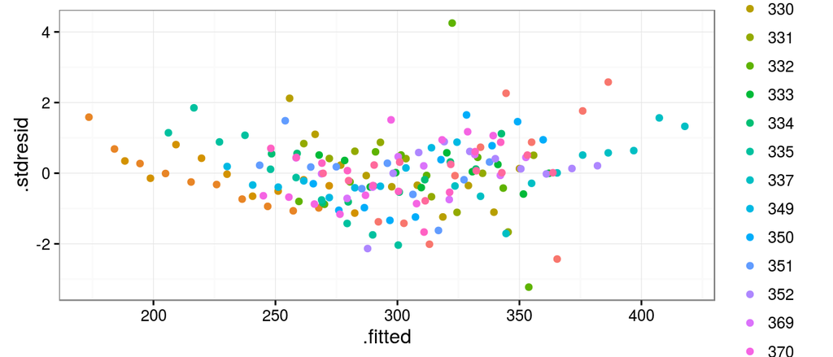

```r
# plot(M1)
sl$.stdresid <- resid(M1, type = "pearson")
sl$.fitted <- fitted(M1)
ggplot(sl) + geom_point(aes(x = .fitted, y = .stdresid, colour = Subject))
```

- Есть большие остатки, гетерогенность дисперсий

## 2) График остатков от ковариат в модели

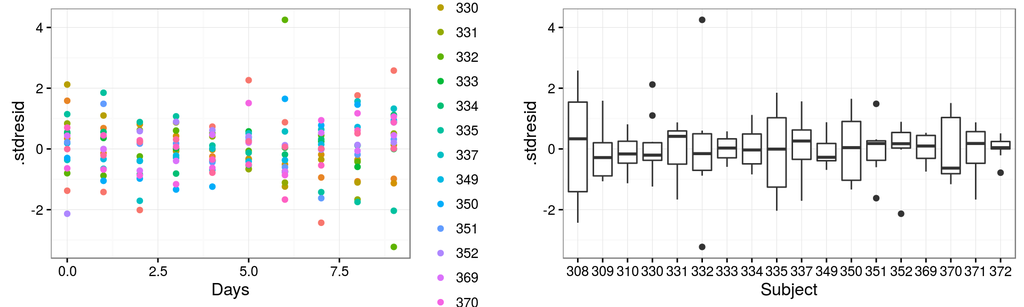

```r
p <- ggplot(data = sl, aes(y = .stdresid))
library(gridExtra)
grid.arrange(
  p + geom_point(aes(x = Days, colour = Subject)),
  p + geom_boxplot(aes(x = Subject)),
  ncol = 2)
```

> - Большой остаток у наблюдения 332 субъекта > - Нелинейный паттерн > - Гетерогенность дисперсий > - Пока оставим все как есть

## 2. Проверяем, какие из фиксированных факторов влияют одним из трех вариантов:

(а) По значениям t-(или -z) статистики (по REML оценке)  
(б) F-критерий - приблизительный результат (REML оценка)  
(в) likelihood ratio test или AIC (ML оценка)  
- Либо попарное сравнение вложенных моделей при помощи likelihood ratio test - Либо сравнение моделей по AIC

## 2(а) По значениям t-(или -z) статистики (по REML оценке)

Дает приблизительный результат; годится для факторов, если не больше 2 уровней

```r
summary(M1)
```

```
## Linear mixed-effects model fit by REML
##  Data: sl
##    AIC  BIC logLik
##   1794 1807   -893
##
## Random effects:
##  Formula: ~1 | Subject
##         (Intercept) Residual
## StdDev:        37.1       31
##
## Fixed effects: Reaction ~ Days
##             Value Std.Error  DF t-value p-value
## (Intercept) 251.4      9.75 161    25.8       0
## Days         10.5      0.80 161    13.0       0
##  Correlation:
##      (Intr)
## Days -0.371
##
## Standardized Within-Group Residuals:
##     Min      Q1     Med      Q3     Max
## -3.2257 -0.5529  0.0109  0.5188  4.2506
##
## Number of Observations: 180
## Number of Groups: 18
```

## 2(б) F-критерий - приблизительный результат (REML оценка)

Зависит от порядка включения предикторов в модель (Type I SS, sequential); годится если один предиктор, либо внимательно интерпретировать.

```r
anova(M1)
```

```
##             numDF denDF F-value p-value
## (Intercept)     1   161    1088  <.0001
## Days            1   161     169  <.0001
```

- Вывод: Время реакции зависит от продолжительности бессонницы

## 2(в1) Попарное сравнение вложенных моделей при помощи likelihood ratio test

Дает более точные выводы, чем F и t(z)

```r
M1.ml <- lme(Reaction ~ Days, random = ~1 | Subject, data = sl, method = "ML")
M2.ml <- update(M1.ml, . ~ . - Days)
anova(M1.ml, M2.ml)
```

```
##       Model df  AIC  BIC logLik   Test L.Ratio p-value
## M1.ml     1  4 1802 1815   -897
## M2.ml     2  3 1917 1926   -955 1 vs 2     116  <.0001
```

df теста - это разница df сравниваемых моделей = 4 - 3 = 1

- Время реакции меняется в зависимости от продолжительности бессонницы (L = 116, df = 1, p < 0.01)

## 2(в2) Сравнение моделей по AIC

```r
AIC(M1.ml, M2.ml)
```

```
##       df  AIC
## M1.ml  4 1802
## M2.ml  3 1917
```

- Т.к. AIC меньше у модели с `Days`, можем написать:
- Продолжительность бессонницы влияет на время реакции (AIC)

## 3. Представление результатов

Для представления результатов переподбираем модель заново, используя Restricted Maximum Likelihood.

REML оценка параметров более точна

```r
MFinal1 <- lme(Reaction ~ Days, random = ~1 | Subject, method = "REML",
    data = sl)
```

Для проверки финальной модели необходимо провести анализ остатков (те же графики, что и в п.1). Поскольку модель не изменилась, не привожу их здесь

## Теперь разберемся с допущениями модели

\[\mathbf{Reaction} _i = \mathbf{X} _i \times \boldsymbol{\beta} + \mathbf{Z} _i \times \mathbf{b} _i + \boldsymbol{\epsilon}_i\]

\(\mathbf{b} _i \sim N(0, \mathbf{D})\) - случайные эффекты \(b _i\) нормально распределены со средним 0 и матрицей ковариаций \(\mathbf{D}\)

\(\boldsymbol{\epsilon} _i \sim N(0, \boldsymbol{\sigma} _i)\) - остатки модели нормально распределены со средним 0 и матрицей ковариаций \(\boldsymbol{\sigma} _i\)

Матрица ковариаций остатков выглядит так: \[\mathbf{\sigma} _i = \sigma^2 \times \left( \begin{array}{cccc} 1 & 0 & 0 & 0 \\ 0 & 1 & \cdots & 0 \\ \vdots & \vdots & \ddots & \vdots \\ 0 & 0 & \cdots & 1 \end{array} \right)\]

Т.е. остатки независимы друг от друга (вне диагонали стоят нули, т.е. ковариация разных остатков 0).

В то же время, отдельные значения переменной-отклика \(Y _i\) уже не будут независимы друг от друга при добавлении случайных эффектов - см. ниже

Можно показать, что \(Y _i\) нормально распределена \(Y _i \sim N(\mathbf{X} _i \times \boldsymbol{\beta}, Cov(\mathbf{Y_i}) )\)

\(Cov(Y_i) = \mathbf{V} _i = \mathbf{Z} _i × \mathbf{D} × \mathbf{Z'} _i + \mathbf{\sigma} _i\) - матрица ковариаций зависимой переменной  
\(\mathbf{D}\) - матрица ковариаций случайных эффектов.

Т.е. **добавление случайных эффектов приводит к изменению ковариационной матрицы** \(Cov(Y_i)\)

Для модели со случайным intercept:

\[Cov(Y_i) = \left( \begin{array}{c} 1 \\ 1 \\ \vdots \\ 1 \end{array}\right) \times d^2 \times \left( \begin{array}{c} 1 & 1 & \cdots & 1 \end{array}\right) + \sigma^2 \times \left( \begin{array}{cccc} 1 & 0 & 0 & 0 \\ 0 & 1 & \cdots & 0 \\ \vdots & \vdots & \ddots & \vdots \\ 0 & 0 & \cdots & 1 \end{array} \right) =\]

\[ = \left( \begin{array}{cccc} \sigma^2 + d^2 & d^2 & \cdots & d^2 \\ d^2 & \sigma^2 + d^2 & \cdots & d^2 \\ \vdots & \vdots & \ddots & \vdots \\ d^2 & d^2 & d^2 & \sigma^2 + d^2 \end{array} \right) \]

## Индуцированная корреляция - следствие включения в модель случайных эффектов

\[Cov(Y_i) = \left( \begin{array}{cccc} \sigma^2 + d^2 & d^2 & \cdots & d^2 \\ d^2 & \sigma^2 + d^2 & \cdots & d^2 \\ \vdots & \vdots & \ddots & \vdots \\ d^2 & d^2 & d^2 & \sigma^2 + d^2 \end{array} \right) \]

\(d^2\) - ковариация между наблюдениями одного субъекта; \(\sigma^2 + d^2\) - дисперсия

Т.е. корреляция между наблюдениями одного субъекта \(d^2 / (\sigma^2 + d^2)\)

### Коэффициент внутриклассовой корреляции \(d^2 / (\sigma^2 + d^2)\)

Способ измерить, насколько коррелируют друг с другом наблюдения из одной и той же группы случайного фактора. Если он высок, то можно брать меньше проб в группе (и больше групп, если нужно)

## Вычисляем внутриклассовую корреляцию

\(sigma_{Subject}^2 / (sigma_{Subject}^2 + sigma^2)\)

```r
MFinal1
```

```
В результатах
Random effects:
 Formula: ~1 | Subject
        (Intercept) Residual
StdDev:    37.12383 30.99123
```

```r
# Внутриклассовая корреляция
37.12383^2/(37.12383^2 + 30.99123^2)
```

```
## [1] 0.589
```

- Значения времени реакции одного субъекта похожи, эффект субъекта нельзя игнорировать в анализе

## График предсказанных значений для результатов

```r
# 1) Новый датафрейм, для которого будем предсказывать
library(dplyr)
minmax <- sl %>% group_by(Subject) %>% summarise(mDays = min(Days), MDays = max(Days))
new_data <- minmax %>% group_by(Subject) %>% do(data.frame(Days = seq(.$mDays,
    .$MDays, length = 10)))

# 2) Матрица линейной модели
X <- model.matrix(~Days, data = new_data)

# 3) Вычисляем предсказанные значения одним из двух способов level = 0
# - для фиксированных эффектов (т.е. без учета субъекта)
new_data$.fitted <- predict(MFinal1, new_data, level = 0)
# или то же самое при помощи матриц
betas = fixef(MFinal1)
new_data$.fitted <- X %*% betas

# 4) Вычисляем стандартные ошибки предсказанных значений это квадратный
# корень из диагональных элементов матрицы ковариаций предсказанных
# значений X * cov(BETA) * t(X)
new_data$.se <- sqrt(diag(X %*% vcov(MFinal1) %*% t(X)))
```

## 1-й вариант. График с предсказаниями по фиксированной части модели

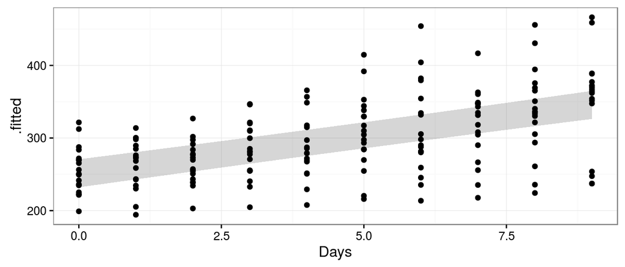

```r
ggplot(new_data) + geom_ribbon(alpha = 0.2, aes(x = Days, y = .fitted,
    ymin = .fitted - 1.98 * .se, ymax = .fitted + 1.98 * .se)) +
    geom_point(data = sl, aes(x = Days, y = Reaction))
```

## 2-й вариант. График с предсказаниями для индивидуальных уровней случайного фактора

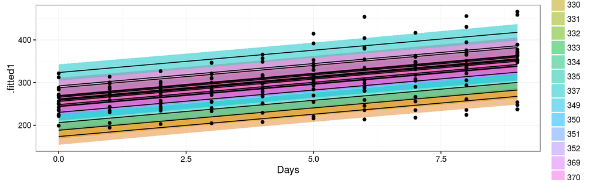

```r
# beta_0 + beta * Days + случайный эффект субъекта
new_data$.fitted1 <- predict(MFinal1, new_data, level = 1)
ggplot(new_data, aes(x = Days, y = .fitted1, group = Subject)) +
    geom_ribbon(aes(fill = Subject, ymin = .fitted1 - 1.98 *
        .se, ymax = .fitted1 + 1.98 * .se), alpha = 0.5) + geom_line() +
    geom_point(data = sl, aes(x = Days, y = Reaction))
```

```r
# попробуйте добавить facet_wrap(~Subject)
```

## смешаные модели со случайным интерсептом и углом наклона

## смешаная модель со случайным интерсептом и углом наклона

На графике индивидуальных эффектов было видно, что измерения для разных субъектов, возможно, идут непараллельными линиями. Усложним модель — добавим случайные изменения угла наклона для каждого из субъектов

```r
MS1 <- lme(Reaction ~ Days, random = ~1 + Days | Subject, data = sl)
```

Дальнейшие действия по прежнему плану: - Анализ остатков - Проверка влияния факторов + подбор оптимальной модели - Визуализация предсказаний

## Задание

Проверьте получившуюся модель MS1

Проведите самостоятельно:

- Анализ остатков
- Проверку влияния факторов + подбор оптимальной модели
- Визуализацию предсказаний

## 1) График остатков от предсказанных значений

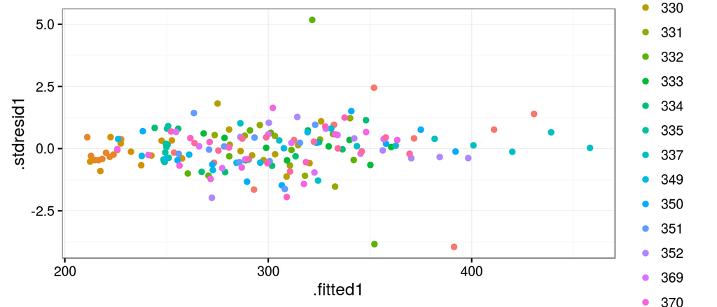

```r
# plot(M1)
sl$.stdresid1 <- resid(MS1, type = "pearson")
sl$.fitted1 <- fitted(MS1)
ggplot(sl) + geom_point(aes(x = .fitted1, y = .stdresid1, colour = Subject))
```

- Есть большие остатки, гетерогенность дисперсий

## 2) График остатков от ковариат в модели

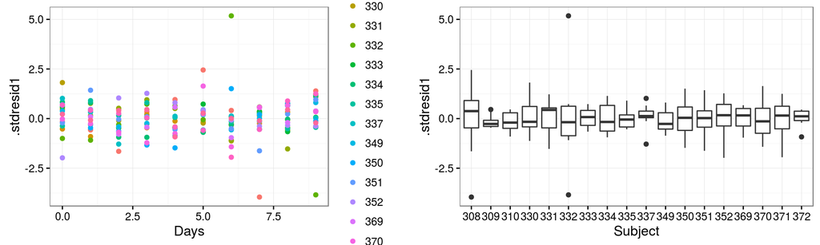

```r
p <- ggplot(data = sl, aes(y = .stdresid1))
grid.arrange(
  p + geom_point(aes(x = Days, colour = Subject)),
  p + geom_boxplot(aes(x = Subject)),
  ncol = 2)
```

> - Большой остаток у наблюдения 332 субъекта > - Нелинейный паттерн > - Гетерогенность дисперсий

## 2. Проверяем, какие из фиксированных факторов влияют при помощи likelihood ratio test

```r
MS1.ml <- lme(Reaction ~ Days, random = ~1 + Days | Subject, data = sl,
    method = "ML")
MS2.ml <- update(MS1.ml, random = ~1 | Subject)
MS3.ml <- update(MS2.ml, . ~ . - Days)
anova(MS1.ml, MS2.ml, MS3.ml)
```

```
##        Model df  AIC  BIC logLik   Test L.Ratio p-value
## MS1.ml     1  6 1764 1783   -876
## MS2.ml     2  4 1802 1815   -897 1 vs 2    42.1  <.0001
## MS3.ml     3  3 1917 1926   -955 2 vs 3   116.5  <.0001
```

- Время реакции меняется в зависимости от продолжительности бессонницы (L = 116, df = 1, p < 0.01). Скорость изменений зависит от субъекта (L = 42, df = 2)

## 3. Представление результатов

Для представления результатов переподбираем модель заново, используя Restricted Maximum Likelihood.

REML оценка параметров более точна

```r
MSFinal <- lme(Reaction ~ Days, random = ~1 + Days | Subject, method = "REML",
    data = sl)
```

```r
# 1) Новый датафрейм, для которого будем предсказывать
library(dplyr)
minmax <- sl %>% group_by(Subject) %>% summarise(mDays = min(Days), MDays = max(Days))
new_data <- minmax %>% group_by(Subject) %>% do(data.frame(Days = seq(.$mDays,
    .$MDays, length = 10)))
# 2) Матрица линейной модели
X <- model.matrix(~Days, data = new_data)
# 3) Предсказанные значения
betas = fixef(MSFinal)
new_data$.fitted <- X %*% betas
# 4) Стандартные ошибки предсказанных значений
new_data$.se <- sqrt(diag(X %*% vcov(MSFinal) %*% t(X)))
```

## 1-й вариант. График с предсказаниями по фиксированной части модели

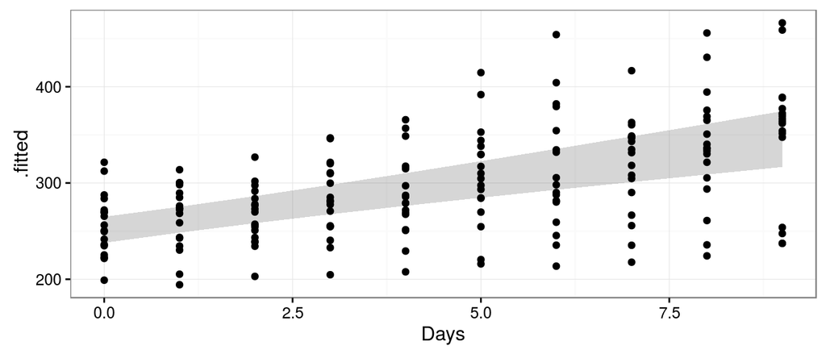

```r
ggplot(new_data) + geom_ribbon(alpha = 0.2, aes(x = Days, y = .fitted,
    ymin = .fitted - 1.98 * .se, ymax = .fitted + 1.98 * .se)) +
    geom_point(data = sl, aes(x = Days, y = Reaction))
```

## 2-й вариант. График с предсказаниями для индивидуальных уровней случайного фактора

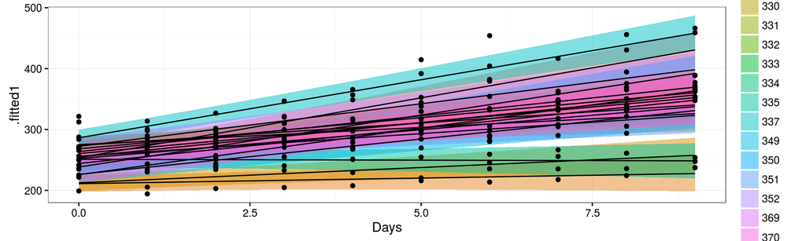

```r
# beta_0 + beta * Days + случайный эффект субъекта
new_data$.fitted1 <- predict(MSFinal, new_data, level = 1)
ggplot(new_data, aes(x = Days, y = .fitted1, group = Subject)) +
    geom_ribbon(aes(fill = Subject, ymin = .fitted1 - 1.98 *
        .se, ymax = .fitted1 + 1.98 * .se), alpha = 0.5) + geom_line() +
    geom_point(data = sl, aes(x = Days, y = Reaction))
```

```r
# попробуйте добавить facet_wrap(~Subject)
```

## Take home messages

- Смешаные модели включают случайные и фиксированные факторы
- Градации фиксированных факторов заранее определены, а выводы можно экстраполировать только на такие уровни, которые были задействованы в анализе. Тестируется гипотеза о значении средних
- Градации случайных факторов - выборка из возможных уровней, а выводы можно экстраполировать на другие уровни. Тестируется гипотеза о дисперсии между группами по фактору.
- Коэффициент внутриклассовой корреляции оценивает, насколько коррелируют друг с другом наблюдения из одной и той же группы случайного фактора

## Дополнительные ресурсы

- Crawley, M.J. (2007). The R Book (Wiley).
- Zuur, A.F., Ieno, E.N., Walker, N., Saveliev, A.A., and Smith, G.M. (2009). Mixed Effects Models and Extensions in Ecology With R (Springer).